# lab5

# Part two: Connecting data

#4. In the person table, dentify drivers (PER_TYP == 1, see FARS manual) and subset on them.

```r
person <- per %>% filter(PER_TYP == 1)
# person
```

```r
person2 <- unique(per$PER_TYP)
# person2
```

#5.Join accident and person table (work out which variable(s) to use)

```r
joined <- left_join(acc, per, by = "ST_CASE")
# joined
```

```r
accper <- acc %>%
  full_join(person, by = c('STATE', 'ST_CASE', 'COUNTY', 'DAY', 'MONTH', 'HOUR', 'MINUTE'))
# accper
```

#6. Tally the number of accidents by day of the week (DAY_WEEK), hour of the day (HOUR) and gender (SEX). Visualize the results.

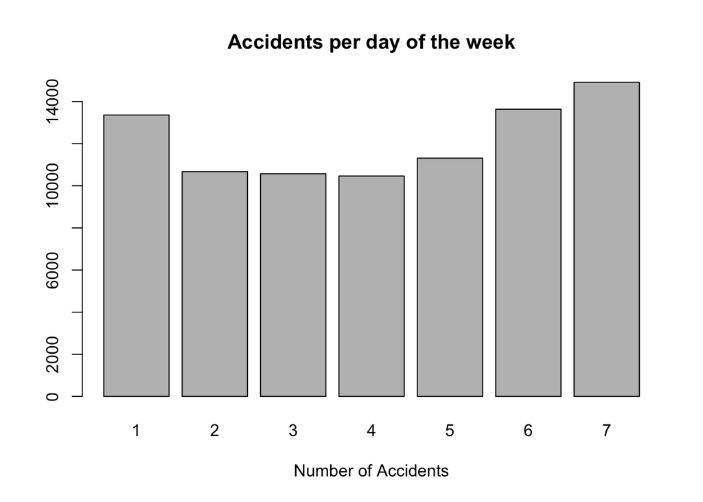

```r
dayofweek <- table(joined$DAY_WEEK)
barplot(dayofweek, main="Accidents per day of the week",
   xlab="Number of Accidents")
```

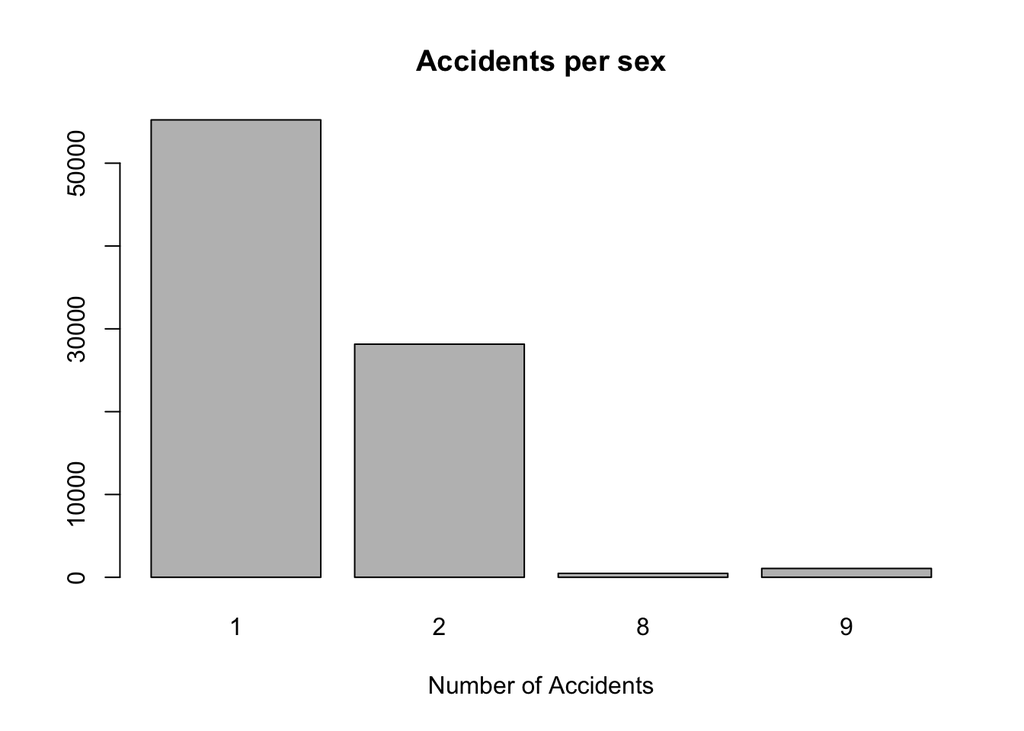

```r
sex <- table(joined$SEX)
barplot(sex, main="Accidents per sex",
   xlab="Number of Accidents")
```

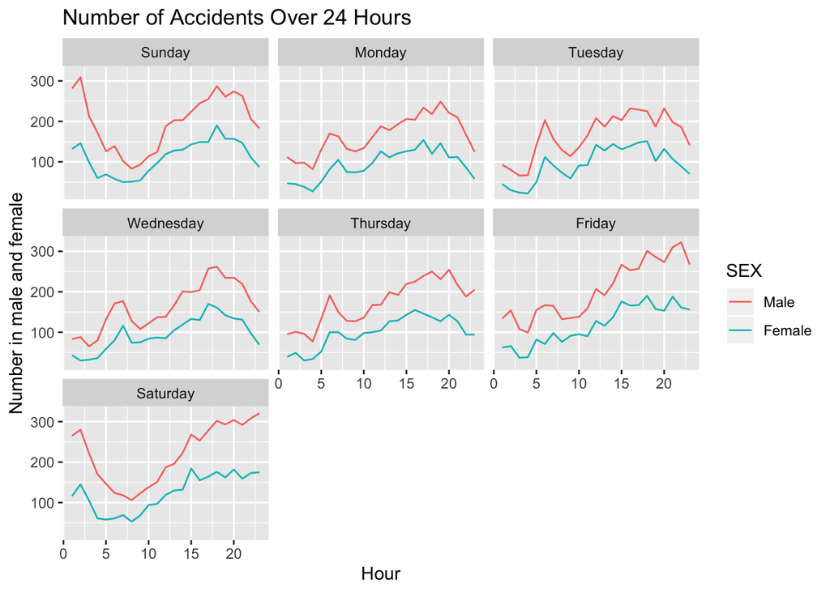

```r
joined <- joined %>%
  filter(HOUR.x, HOUR.x < 25) %>%
  filter(SEX, SEX <= 2) %>%
  mutate(SEX = as.factor(SEX)) %>%
  mutate(DAY_WEEK = as.factor(DAY_WEEK))
levels(joined$SEX) <- c("Male", "Female")
levels(joined$DAY_WEEK) <- c("Sunday", "Monday", "Tuesday",
                            "Wednesday", "Thursday", "Friday",
                            "Saturday")
joined %>%
  group_by(DAY_WEEK, HOUR.x, SEX) %>%
  summarize(count = length(unique(ST_CASE))) %>%
  ggplot(aes(x = HOUR.x, y = count, color = SEX)) +
  geom_line() +
  facet_wrap(~DAY_WEEK) +
  ggtitle("Number of Accidents Over 24 Hours") +
  xlab("Hour") + ylab("Number in male and female")
```

# summary: through plots, we can find that the accidents for the male are great than accident to female in the weekend.

# Part three: Connecting data and make maps

#7 Now plot a choropleth map of accidents on a county level #Read the description for the STATE and COUNTY columns in the FARS manual. The state & county codes are Geographic Locator Codes (GLCs) from the General Services Administration’s (GSA) publication #Use readxl::read_xlsx to read in the GLCs

#8 Visualize the number of accidents in each county using a choropleth map. To do this, you need to join the accident data, GLCs, and appropriate map data.

```r
glcs <- readxl::read_xlsx("FRPP GLC - United StatesFeb132020.xlsx")
glcs <- glcs %>%
   select('State Name', STATE = 'State Code', COUNTY = 'County Code', 'County Name') %>%
   unique()
```

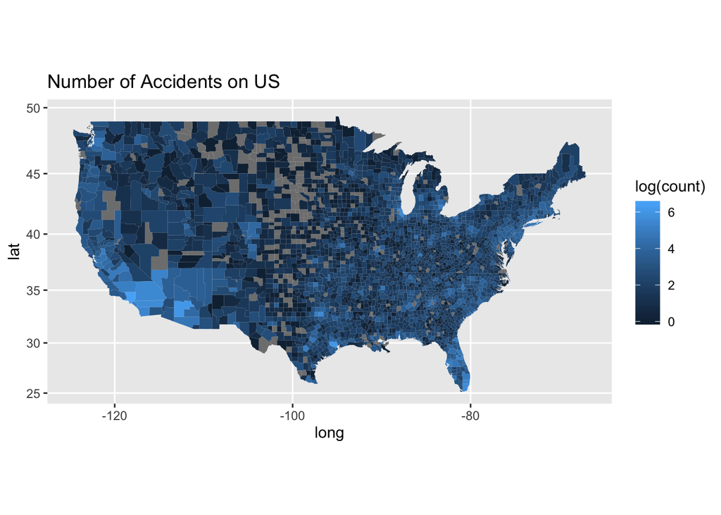

```r
names(glcs)[names(glcs) == "State Code"] <- "STATE"
names(glcs)[names(glcs) == "County Code"] <- "COUNTY"
glcs <- glcs %>%
  mutate(STATE = as.numeric(STATE)) %>%
  mutate(COUNTY = as.numeric(COUNTY))
names(glcs)[names(glcs) == "State Name"] <- "region"
names(glcs)[names(glcs) == "County Name"] <- "subregion"
glcs <- glcs %>%
  mutate(region = tolower(region)) %>%
  mutate(subregion = tolower(subregion))
counties <- map_data('county')
acc8 <- acc %>%
  group_by(STATE, COUNTY) %>%
  summarize(count = n())

local <- left_join(counties, glcs, by = c("region" = "region",
                                   "subregion" = "subregion"))
local <- left_join(local, acc8, by = c("STATE" = "STATE",
                                   "COUNTY" = "COUNTY"))
local %>%
ggplot(aes(x = long, y = lat, fill = log(count))) +
  geom_polygon(aes(group=group)) +
  ggtitle("Number of Accidents on US") +
  coord_map()
```

#9. Can you find seasonal trends in accident occurrences in different states? Is summer or winter more dangerous? Why?

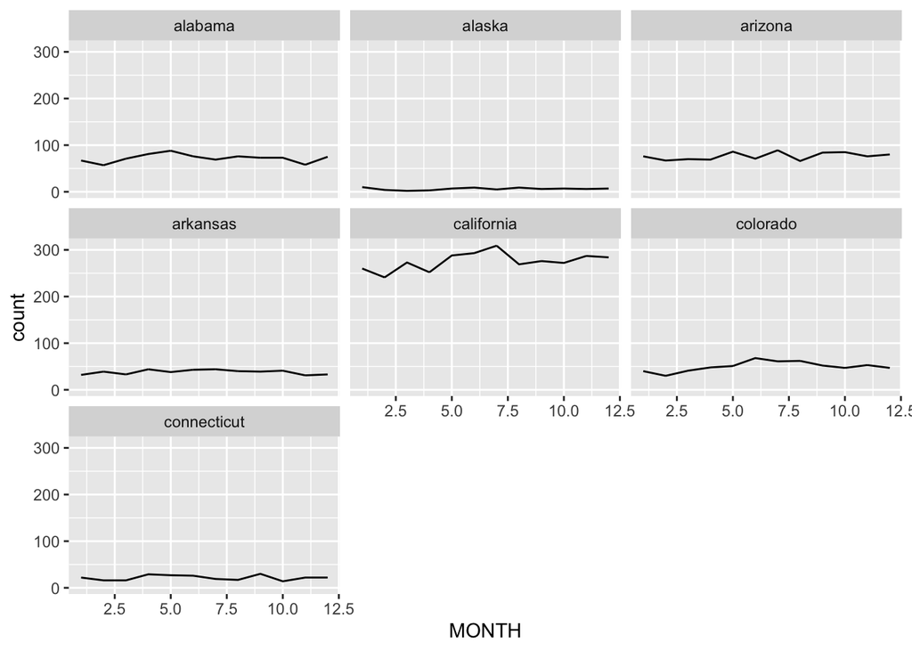

```r
acc91 <- acc %>%
  filter(STATE %in% c(1,2,3,4,5,6,7,8,9)) %>%
  group_by(STATE, MONTH) %>%
  summarize(count = n())
acc92 <- acc %>%
  filter(STATE %in% c(10,11,12,13,14,15,16,17,18)) %>%
  group_by(STATE, MONTH) %>%
  summarize(count = n())
acc93 <- acc %>%
  filter(STATE %in% c(19,20,21,22,23,24,25,26,27)) %>%
  group_by(STATE, MONTH) %>%
  summarize(count = n())
acc94 <- acc %>%
  filter(STATE %in% c(28,29,30,31,32,33,34,35,36)) %>%
  group_by(STATE, MONTH) %>%
  summarize(count = n())
acc95 <- acc %>%
  filter(STATE %in% c(37,38,39,40,41,42,43,44,45)) %>%
  group_by(STATE, MONTH) %>%
  summarize(count = n())
acc96 <- acc %>%
  filter(STATE %in% c(46,47,48,49,54,55,56)) %>%
  group_by(STATE, MONTH) %>%
  summarize(count = n())
left_join(acc91, glcs) %>%
  ggplot(aes(x = MONTH, y = count)) +
  geom_line() +
  facet_wrap(~region)
```

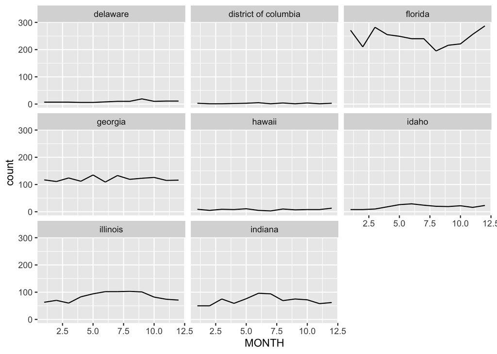

```r
left_join(acc92, glcs) %>%
  ggplot(aes(x = MONTH, y = count)) +
  geom_line() +
  facet_wrap(~region)
```